# Лабораторна робота №2.Налагоджування та робота в середовищі Anaconda+Quarto.

## 1.Завантаження та встановлення збірки Python Anaconda

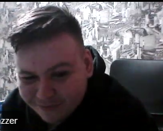

[figure not shown]

## 2.Через інтерфейс командного рядка налагодити за допомогою conda віртуальне середовище з ім’ям StudentLastName_OpenCV. Етапи роботи підтвердити скріншотами.

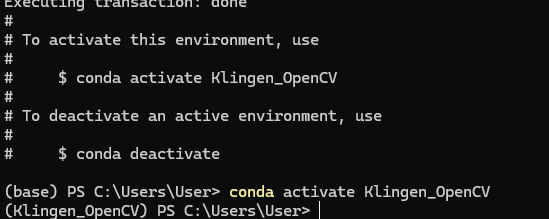

## 3.Проінсталювати у створене середовище пакети, необхідні для роботи з OpenCV.

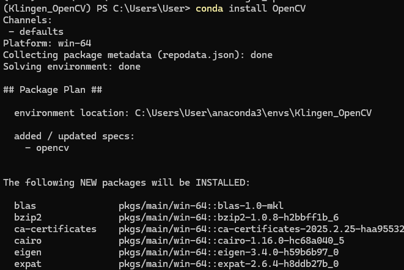

## 4.Контрольні питання.

- Що таке pip і conda та чим вони відрізняються між собою? - pip це стандартний менеджер пакетів , який може бути використаний будь де , де встановлено Python , а conda це менеджер пакетів що використовуються в Anaconda , має вбудований менеджер середовищ та може бути використаний поза Python.
- Як виглядатиме виконання пунктів 1–3 індивідуального завдання за допомогою Virtualenv? - 1.Створити директорію та перейти в неї (mkdir test/cd test) 2.Створити віртуальне середовище (virtualenv (name)) 3.Зайти в середовище (source (name)/bin/activate) 4.Написати команду (pip install opencv-python).
- Сфотографувати себе на телефон та імпортувати своє зображення у форматі .png на початок робочого зошита. - Зробленo
- Написати процедуру на Python сортування масиву методом бульбашки. - нижче приведено фото.
- Як виконати компіляцію вхідного документа Jupyter Notebook з його середовища, не використовуючи інтерфейс командного рядка? - File -> Download as та вибрати потрібний формат файлу
- Як виконати компіляцію вхідного документа у Quarto? - quarto preview <ім’я документа>.

```python
def bubble_sort(arr):
    n = len(arr)
    for i in range(n):
        swapped = False
        for j in range(n - i - 1):
            if arr[j] > arr[j + 1]:
                arr[j], arr[j + 1] = arr[j + 1], arr[j]  # Обмін елементів
                swapped = True
        if not swapped:  # Якщо не було жодного обміну, завершити сортування
            break
    return arr
```